# Simulation-Based Inference

JMM 2016

## Simulation-Based Inference with mosaic

## You can do() it!

## Basic ideas

### Traditional Approach

- Sampling distributions approximated by theoretical distributions
- parameters of these distributions are estimated from data
- p-values and CIs based on formulas & estimated parameters

\[ t = \frac{ \overline{x} - \mu}{s / \sqrt{n}} \]

### SBI Approach

- Sampling distributions are approximated by simulation
- p-values and CIs are computed from simulated data

## The Lady Tasting Tea

- Often used on first day of class
- Story
  - woman claims she can tell whether milk has been poured into tea or vice versa.
  - Question: How do we test this claim?
- Can replace with any test of a proportion
  - fair coin, Dorris and Buzz, multiple-choice guessing, ESP, Hugo, …

## Computer Simulation

Use `rflip()` to simulate flipping coins

```r
rflip()
```

```
##
## Flipping 1 coin [ Prob(Heads) = 0.5 ] ...
##
## H
##
## Number of Heads: 1 [Proportion Heads: 1]
```

## Computer Simulation

Faster if we flip multiple coins at once:

```r
rflip(10)
```

```
##
## Flipping 10 coins [ Prob(Heads) = 0.5 ] ...
##
## H H H T T T H H H T
##
## Number of Heads: 6 [Proportion Heads: 0.6]
```

- easier to consider `heads` = correct; `tails` = incorrect than to compare with a given pattern
- this switch bothers me more than it bothers my students

## Let's do that a lot of times

`rflip(10)` simulates 1 lady tasting 10 cups 1 time.

We can do that many times to see how guessing ladies do:

```r
do(2) * rflip(10)
```

```
##    n heads tails prop
## 1 10     6     4  0.6
## 2 10     5     5  0.5
```

- `do()` is clever about what it remembers
- 2 isn't many – we'll do many next.

## The distribution of guessing ladies

```r
Ladies <- do(5000) * rflip(10)
head(Ladies, 1)
```

```
##    n heads tails prop
## 1 10     4     6  0.4
```

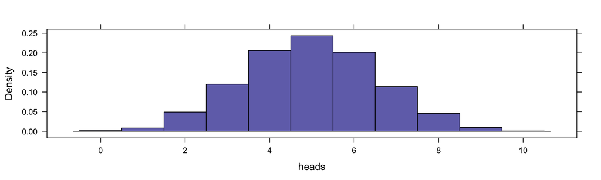

```r
histogram( ~ heads, data = Ladies, width = 1 )
```

## How often does guessing score 9 or 10?

```r
tally( ~(heads >= 9) , data = Ladies)
```

```
##
##  TRUE FALSE
##    52  4948
```

## How often does guessing score 9 or 10?

```r
tally( ~(heads >= 9) , data = Ladies,
                       format = "prop")
```

```
##
##   TRUE  FALSE
## 0.0104 0.9896
```

## How often does guessing score 9 or 10?

```r
tally( ~(heads >= 9) , data = Ladies,
                       format = "prop")
```

```
##
##   TRUE  FALSE
## 0.0104 0.9896
```

```r
 prop( ~(heads >= 9), data = Ladies)
```

```
##   TRUE
## 0.0104
```

## A general approach to randomization

## Three Step Program

1. Do it for **your data**
2. Do it for **random data**
3. Do it **lots of** times for **random data**

definition of *it* is usually natural

definition of *random* is important … but can often be handled by

- `shuffle()` or
- `resample()`

## Example: Is there a difference in means?

Data: `HELPrct`

Question: Do the mean ages of men and women differ?

- Of course, there will be a difference in our data
- Want to know whether that difference could be due merely to randomness

## Example: Do mean ages differ by sex?

```r
diffmean(age ~ sex, data = HELPrct)
```

```
##   diffmean
## -0.7841284
```

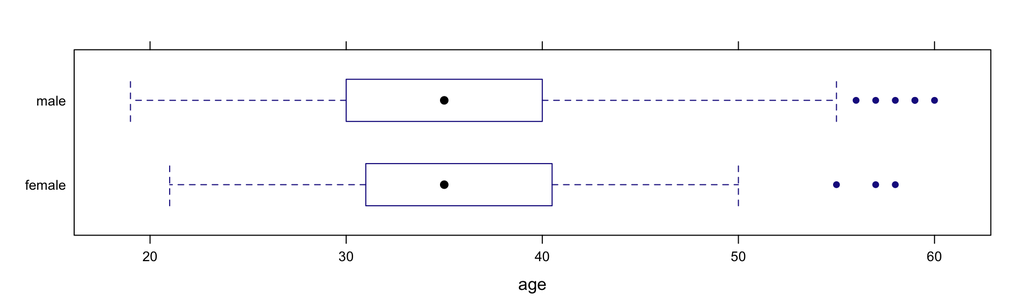

```r
bwplot( sex ~ age, data = HELPrct)
```

## Example: Do mean ages differ by sex?

```r
do(1) *
  diffmean(age ~ shuffle(sex), data = HELPrct)
```

```
##    diffmean
## 1 0.1090973
```

```r
Null <- do(5000) *
  diffmean(age ~ shuffle(sex), data = HELPrct)
```

## Example: Do mean ages differ by sex?

```r
2 * prop( ~ (diffmean <= -0.7841), data = Null)
```

```
##   TRUE
## 0.3588
```

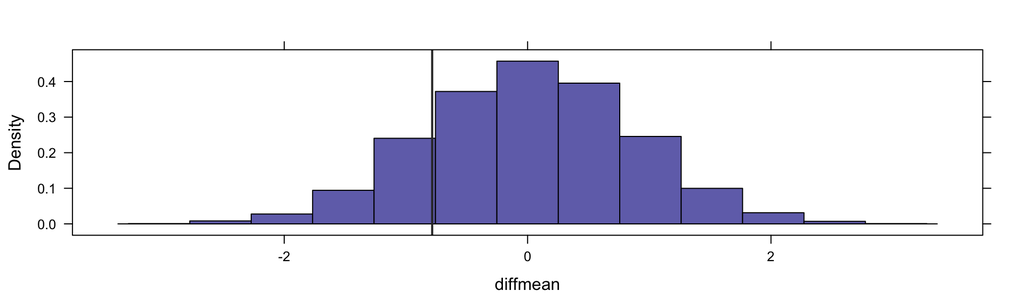

```r
histogram( ~ diffmean, data = Null, v = -.7841)
```

## A Little Wrinkle

We should include the observed test statistic in the Null Distribution.

- If the Null Hypothesis is true, the observed test statistic belongs
- Avoids the problem of obtaining a p-value of 0

`prop`()` computes proportions after adding 1 to numerator and denominator.

```r
2 * prop1( ~ (diffmean <= -0.7841), data = Null)
```

```
##      TRUE
## 0.3591282
```

## Example: Bootstrap for difference in means

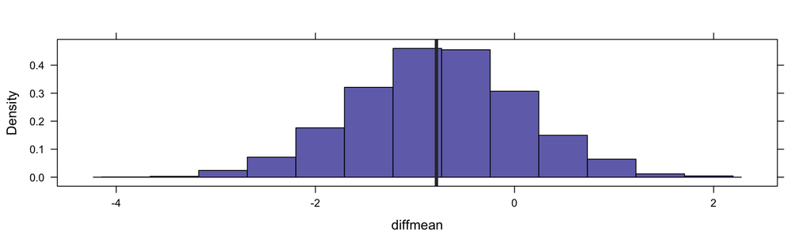

```r
Bootstrap <- do(5000) *
  diffmean(age ~ sex, data= resample(HELPrct))

histogram( ~ diffmean, data = Bootstrap,
                      v = -.7841, glwd = 4 )
```

## Example: CI for difference in mean ages

autosize: true

```r
cdata( ~ diffmean, data = Bootstrap, p = .95)
```

```
##        low         hi  central.p
## -2.4787104  0.8894968  0.9500000
```

```r
confint(Bootstrap, method = "quantile")
```

```
##       name    lower     upper level     method   estimate
## 1 diffmean -2.47871 0.8894968  0.95 percentile -0.7841284
```

## Example: CI for difference in mean ages

autosize: true

```r
confint(Bootstrap)  # default uses st. err
```

```
##       name     lower     upper level method   estimate margin.of.error  df
## 1 diffmean -2.433334 0.8937444  0.95 stderr -0.7841284        1.663539 452
```

## Randomization and linear models

```r
do(1) * lm(width ~ length, data = KidsFeet)
```

```
##   Intercept    length     sigma r.squared        F numdf dendf
## 1  2.862276 0.2479478 0.3963356 0.4110041 25.81878     1    37
```

```r
do(3) * lm(width ~ shuffle(length), data = KidsFeet)
```

```
##   Intercept     length.     sigma   r.squared         F numdf dendf
## 1 11.639314 -0.10706623 0.4962420 0.076635651 3.0708562     1    37
## 2 11.541875 -0.10312500 0.4977279 0.071097404 2.8319481     1    37
## 3  9.754237 -0.03081856 0.5147824 0.006349662 0.2364388     1    37
```

## Randomization and linear models

```r
do(1) *
  lm(width ~ length + sex, data = KidsFeet)
```

```
##   Intercept   length       sexG     sigma r.squared        F numdf dendf
## 1  3.641168 0.221025 -0.2325175 0.3848905 0.4595428 15.30513     2    36
```

```r
do(3) *
  lm( width ~ length + shuffle(sex),
                       data = KidsFeet)
```

```
##   Intercept    length       sex.G     sigma r.squared        F numdf dendf
## 1  2.942851 0.2431545  0.07785347 0.3998086 0.4168355 12.86608     2    36
## 2  3.450856 0.2282462 -0.20833605 0.3878261 0.4512672 14.80285     2    36
## 3  2.842685 0.2484316  0.01565872 0.4017205 0.4112447 12.57297     2    36
```

## Randomization and linear models

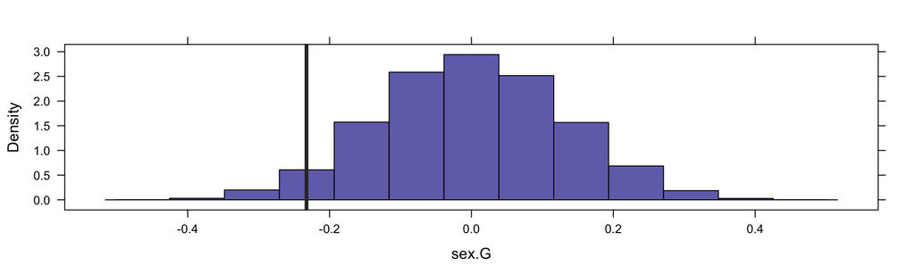

```r
Null <- do(5000) *
  lm(width ~ length + shuffle(sex), data = KidsFeet)
histogram( ~ sex.G, data = Null,
           v = -0.2325, glwd = 4)
```

## Randomization and linear models

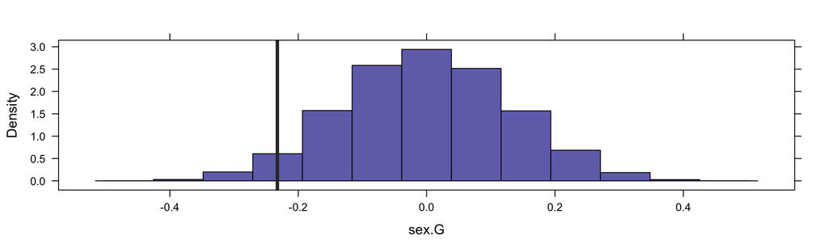

```r
histogram(~ sex.G, data = Null,
           v = -0.2325, glwd = 4)
```

```r
prop1(~ (sex.G <= -0.2325), data = Null)
```

```
##       TRUE
## 0.03719256
```